```python
import numpy as np
from scipy.stats import norm
import copy
import time
import matplotlib.pyplot as plt
```

# *Assignment 3*

Welcome to Assignment 3! In this assignment you are allowed to work *individually or in pairs*. It is worth 30 points in total. Exercise 1 is worth 3 points, Exercise 2 is worth 2 points, Exercises 3 and 4 are worth 10 points each, and Exercise 5 is worth 5 points. There is a 5 point minimum for passing this assignment (you need to pass all four assignments to be able to pass the course, see the grade chart on the Canvas course page for more details).

Submission details: Your submission should contain two pdf's.

1. A pdf version of your filled out colaboratory on Canvas. You can do this by pressing `cmd/ctrl+p` (you know the drill from there).
2. For Exercise 1, you need to hand in your hand-written solutions in a LaTeX pdf. We only accept solutions written in LaTeX, i.e. not Word or any other text editor. We recommend [Overleaf](https://overleaf.com), if you do not already have a favourite LaTeX editor (which is also [provided by KTH](https://intra.kth.se/en/it/programvara-o-system/programvara/installera/download/overleaf/overleaf-1.932755)).

# Contents

In this assignment we will cover the following topics (not necessarily in this order):

- Derivations of the Importance Weights
- Generate and Visualize the Data
- Sequential Importance Sampling
- Bootstrap Particle Filter
- Parameter Inference

# *1. Derivations of the Importance Weights*

*For this exercise, submit your solution in a separate pdf (written in LaTeX) to avoid point deduction*

In the lectures, we saw that the importance weights in SMC can be written as

$\begin{equation} w_n = \frac{p(y_{1:n}|x_{1:n})p(x_{1:n})}{q(x_{1:n})}, \end{equation}$ where $x_{1:n} \sim q(x_{1:n}).$

However, as we discussed, it is difficult to sample directly from $q(x_{1:n})$, and difficult to evaluate $w_n$ (when in the form above). Luckily we can make some simplifying assumptions by observing that we are dealing with a hidden Markov model (HMM). Your task is to show, based on these simplifying assumptions that, $$w_n = \frac{p(y_{1:n}|x_{1:n})p(x_{1:n})}{q(x_{1:n})}=\alpha(x_{n})w_{n-1},$$ where $$x_{n}\sim q(x_n|x_{n-1})$$ $$\alpha(x_{n}) =\frac{p(y_{n}|x_{n})p(x_{n}|x_{n-1})}{q(x_{n}|x_{n-1})}$$ $$w_{n-1}=\frac{p(y_{1:n-1}|x_{1:n-1})p(x_{1:n-1})}{q(x_{1:n-1})}$$

## **Hint: take the following steps**

**1) Enumerate the simplifying assumptions needed**

In the associated lecture we went through a couple of (HMM-related) assumptions and properties that should be useful.

**2) Attack the problem term by term**

Work with $p(y_{1:n}|x_{1:n})$, $p(x_{1:n})$ and $q(x_{1:n})$ separately.

**3) Put the terms together**

Once you have expressions for the three separate terms above, put them back into $w_n$ and show that you can re-write it as $$w_n =\alpha(x_{n})w_{n-1},$$

# *2. The Stochastic Volatility Model*

In this assignment you will work with the stochastic volatililty (SV) model, which was covered in class:

$$\begin{equation*} x_1 \sim \mathcal{N}(0, \frac{\sigma^2}{1 - \alpha ^2}), \end{equation*}$$$$\begin{equation*} x_n \sim \mathcal{N}(\alpha x_{n-1}, \sigma^2), \end{equation*}$$$$\begin{equation*} y_n \sim \mathcal{N}(0, \beta^2\exp(x_{n})), \end{equation*}$$

for $n=1,...,T$.

Now, let $T=100$, $\beta=0.64$, $\alpha=0.91$ and $\sigma=1$, and generate data according to the SV model. Then visualize $x_{1:T}$ and $y_{1:T}$ in cells below, in a similar manner as plots in the lecture slides. *Importantly, use correct legends, a title, and x- and y-labels. Failing to include these items will lead to point deduction. This applies for all plots in this assignment.*

```python
np.random.seed(173710)

sigma = 1
alpha = .91
beta = .64

x_n = np.empty(0)
y_n = np.empty(0)

x_n = np.append(x_n, np.random.normal(loc=0, scale=(sigma**2/(1-alpha**2))))
y_n = np.random.normal(loc=0, scale=((beta**2)*np.exp(x_n)))
for n in range(1,100):
    x_n = np.append(x_n, np.random.normal(loc=(alpha*x_n[n-1]), scale=(sigma**2)))
    y_n = np.append(y_n, np.random.normal(loc=0, scale=((beta**2)*np.exp(x_n[n]))))
```

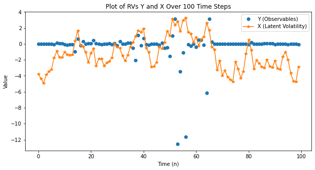

```python
# Visualize the data here
plt.rc("figure", figsize=(10,5))
plt.plot(y_n, 'o')
plt.plot(x_n, '*-')
plt.xlabel("Time (n)")
plt.ylabel("Value")
plt.legend(["Y (Observables)","X (Latent Volatility)"])
plt.title("Plot of RVs Y and X Over 100 Time Steps")
```

# *3. Sequential Importance Sampling*

Here you will implement the sequential importance sampling (SIS) algorithm in order to

1. Estimate $x_n$ at each time step $n$.

To do so, the expression for the filtering estimate at time $n$ will be useful. Write it in the cell below:

*The filtering estimate for SIS is:*

\begin{equation} p(x_n | y_{1:n}) \approx \sum_{k=1}^K \tilde{w}_n^k \delta_{x_n^k}(x_n) \end{equation}

*where $\tilde{w}_n^k = \frac{w_n^k}{\sum_k^Kw_n^k}$ is the normalized weight.*

The filtering estimate above is indeed a pdf. To estimate $x_n$ use the mean of the filtering estimate at each $n$, and refer to it as $\hat{x}_n$. Report the mean squared error (MSE) between $\hat{x}_n$ and $x_n$, averaged over all $n$ (i.e., we are expecting a single value).

Additionally, you should

1. Visualize the degeneracy of the importance weights using a histogram for $n=2, 5, 50, 100$
2. Visualize the path/trajectory degeneracy by sampling from your SIS approximation of $p(x_{1:T}|y_{1:T})$. Clearly explain how you sample from the distribution (see the lecture slides for hints)!

In order to implement the SIS, you will first need to choose a proposal distribution, $q(x_n|x_{n-1})$. For simplicity, let $q(x_n|x_{n-1}) = p(x_n|x_{n-1})$.

Start out by using $K=100$ particles.

1. How do the MSE scores change when you instead use $K=5$ and $K=500$ particles? Explain your results. **Answer in a text cell after your code cells, and report the MSEs there.**

```python
# Implement SIS here (without resampling)
np.random.seed(173710)

K = 100  #nr. of particles to generate
N = 100  #nr. of time steps

xgen_n = {}
w_n = {}

xgen_n[0] = np.random.normal(loc=0, scale=(sigma**2/(1-alpha**2)), size=K) #because q(x_1) = p(x_1)
w_n[0] = norm.pdf(y_n[0], loc=0, scale=((beta**2)*np.exp(xgen_n[0])))
w_n[0] /= w_n[0].sum()

for n in range(1,N):
    xgen_n[n] = np.random.normal(loc=(alpha*xgen_n[n-1]), scale=(sigma**2))
    w_n[n] = norm.pdf(y_n[n], loc=0, scale=((beta**2)*np.exp(xgen_n[n]))) * w_n[n-1]
    w_n[n] /= w_n[n].sum()
```

```python
all_w = np.empty(0)
all_xgen = np.empty(0)
for (key1,values1), (key2,values2) in zip(w_n.items(), xgen_n.items()):
    all_w = np.append(all_w, copy.deepcopy(values1))
    all_xgen = np.append(all_xgen, copy.deepcopy(values2))
```

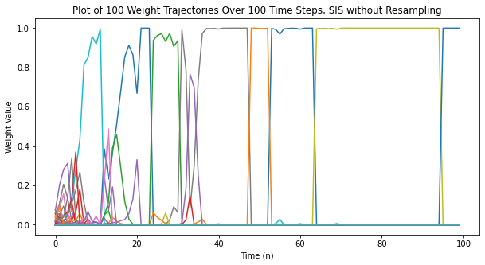

```python
for k in range(K):
    plt.plot(all_w[np.arange(k, all_w.size, K)])

plt.xlabel("Time (n)")
plt.ylabel("Weight Value")
plt.title("Plot of " + str(K) + " Weight Trajectories Over 100 Time Steps, SIS without Resampling")
plt.show()
```

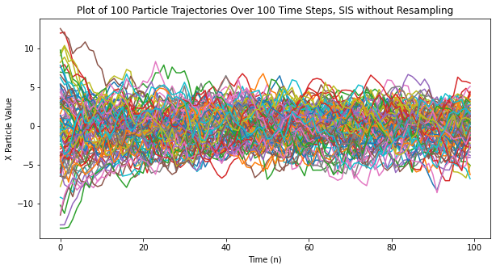

```python
for k in range(N):
    plt.plot(all_xgen[np.arange(k, all_xgen.size, K)])

plt.xlabel("Time (n)")
plt.ylabel("X Particle Value")
plt.title("Plot of " + str(K) + " Particle Trajectories Over 100 Time Steps, SIS without Resampling")
plt.show()
```

```python
xhat_n = [np.dot(all_xgen[n:(n+K)], all_w[n:(n+K)]) for n in range(0, len(all_xgen), K)]
print(xhat_n)
```

```
[-4.82397622906499, -5.098920237642669, -4.739071245903471, -3.1198679816565438, -3.153973204229181, -3.247509681965645, -2.2149124213717353, -0.295259025903415, -0.08687879016071542, -0.8152771434044827, 0.3220635159458701, -1.1643149316622332, 1.097688518087007, -1.1387258125929833, 0.218252552617…
```

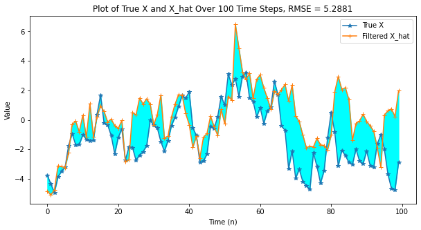

```python
rmse = ((xhat_n - x_n)**2).mean()

plt.rc("figure", figsize=(10,5))
plt.plot(x_n, '*-')
plt.plot(xhat_n, '+-')
plt.fill_between(np.arange(N), x_n, xhat_n, color="cyan")
plt.xlabel("Time (n)")
plt.ylabel("Value")
plt.legend(["True X", "Filtered X_hat"])
plt.title("Plot of True X and X_hat Over 100 Time Steps, RMSE = " + str(round(rmse,4)))
```

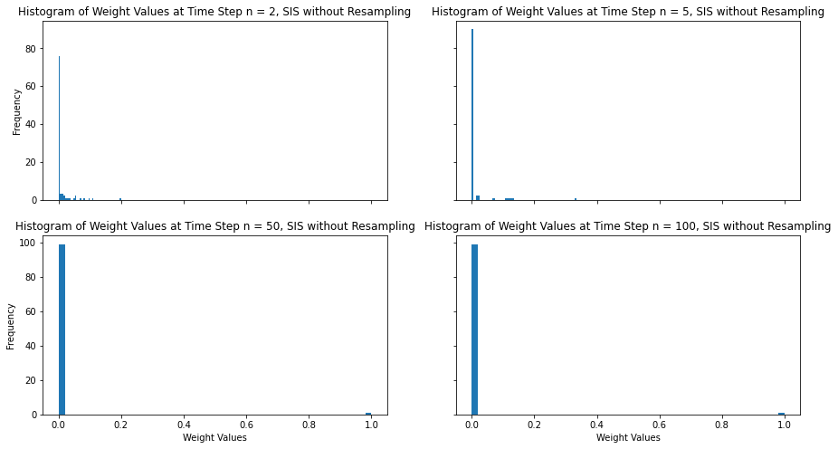

```
Iteration 2 the smallest weight is 0.0 and the largest one is 0.20011
Iteration 5 the smallest weight is 0.0 and the largest one is 0.33615
Iteration 50 the smallest weight is 0.0 and the largest one is 1.0
Iteration 100 the smallest weight is 0.0 and the largest one is 1.0
```

```python
n = [2, 5, 50, 100]

i = 0
fig = plt.figure(figsize=(15,8))
gs = fig.add_gridspec(2, 2, hspace=0.2, wspace=0.2)
axs = gs.subplots(sharex='col', sharey='row')
for x in range(2):
    for y in range(2):
        axs[x][y].hist(all_w[(n[i]-1)*K:n[i]*K], bins=50)
        axs[x][y].set_title("Histogram of Weight Values at Time Step n = " + str(n[i]) + ", SIS without Resampling")
        i += 1

plt.setp(axs[-1, :], xlabel='Weight Values')
plt.setp(axs[:, 0], ylabel='Frequency')
plt.show()

for i in range(4):
    print("Iteration " + str(n[i]) + " the smallest weight is " + str(round(all_w[(n[i]-1)*K:n[i]*K].min(),5)) + " and the largest one is " + str(round(all_w[(n[i]-1)*K:n[i]*K].max(),5)))
```

### Answers to Q3.2 & Q3.3 (1); see below for part (2)

*Without resampling, it can clearly be seen that path degeneracy is a problem, as the number of paths having weights 0 ("dead trajectories") keeps increasing over the time steps and a single path accumulates more weight to eventually reach 1. At this point, all other particles are "dead" and only this single one survives (evident already at time step 50). Thus, at least during half of the time course, only a single particle is exploring the state space, severely reducing the effectiveness of the sampling process.*

```python
# Implement SIS here (with resampling)
np.random.seed(173710)

K = 100  #nr. of particles to generate
N = 100  #nr. of time steps

xgen_n = {}
w_n = {}
resampling = [0]

xgen_n[0] = np.random.normal(loc=0, scale=(sigma**2/(1-alpha**2)), size=K) #because q(x_1) = p(x_1)
w_n[0] = norm.pdf(y_n[0], loc=0, scale=((beta**2)*np.exp(xgen_n[0])))
w_n[0] /= w_n[0].sum()

for n in range(1,N):
    xgen_n[n] = np.random.normal(loc=(alpha*xgen_n[n-1]), scale=(sigma**2))
    w_n[n] = norm.pdf(y_n[n], loc=0, scale=((beta**2)*np.exp(xgen_n[n]))) * w_n[n-1]
    w_n[n] /= w_n[n].sum()

    #resampling every time there are dead particles
    if (w_n[n]==0).sum():
        u = np.random.uniform(0, w_n[n].max())
        sort_w_n = copy.deepcopy(w_n[n])
        sort_w_n.sort()
        which_w = sort_w_n[next(x[0] for x in enumerate(sort_w_n) if x[1] > u)]
        which_k = np.where(w_n[n] == which_w)
        xgen_n[n][:K] = xgen_n[n][which_k]
        w_n[n][:K] = 1/K
        resampling.append(1)
    else:
        resampling.append(0)
```

```python
all_w2 = np.empty(0)
all_xgen2 = np.empty(0)
for (key1,values1), (key2,values2) in zip(w_n.items(), xgen_n.items()):
    all_w2 = np.append(all_w2, copy.deepcopy(values1))
    all_xgen2 = np.append(all_xgen2, copy.deepcopy(values2))
```

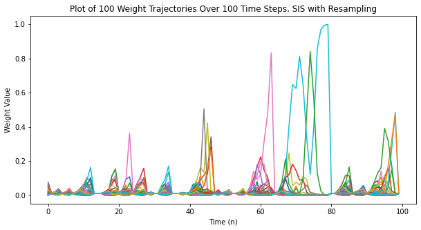

```python
for k in range(K):
    plt.plot(all_w2[np.arange(k, all_w2.size, K)])

plt.xlabel("Time (n)")
plt.ylabel("Weight Value")
plt.title("Plot of " + str(K) + " Weight Trajectories Over 100 Time Steps, SIS with Resampling")
plt.show()
```

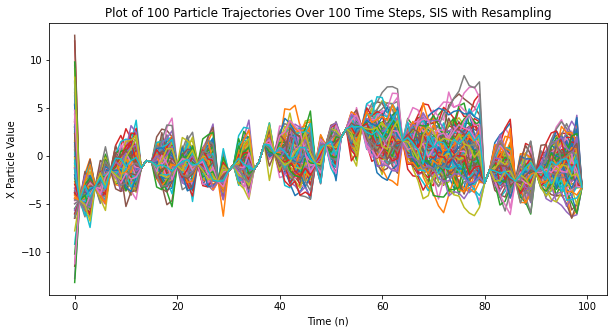

```python
for k in range(N):
    plt.plot(all_xgen2[np.arange(k, all_xgen2.size, K)])

plt.xlabel("Time (n)")
plt.ylabel("X Particle Value")
plt.title("Plot of " + str(K) + " Particle Trajectories Over 100 Time Steps, SIS with Resampling")
plt.show()
```

```python
xhat2_n = [np.dot(all_xgen2[n:(n+K)], all_w2[n:(n+K)]) for n in range(0, len(all_xgen2), K)]
print(xhat2_n)
```

```
[-4.82397622906499, -4.581929710662713, -4.540371729304123, -3.970337121002174, -3.171827832304374, -3.082051392093794, -2.092126293405367, -1.4886486902851441, -1.6574988021017507, -2.061682876365542, -1.5165917816358814, -1.0591465359314538, -1.2401489441954932, -1.2255768962110873, -0.46985446924…
```

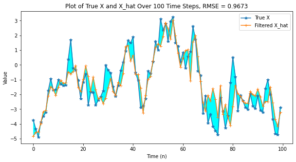

```python
rmse = ((xhat2_n - x_n)**2).mean()

plt.rc("figure", figsize=(10,5))
plt.plot(x_n, '*-')
plt.plot(xhat2_n, '+-')
plt.fill_between(np.arange(N), x_n, xhat2_n, color="cyan")
plt.xlabel("Time (n)")
plt.ylabel("Value")
plt.legend(["True X", "Filtered X_hat"])
plt.title("Plot of True X and X_hat Over 100 Time Steps, RMSE = " + str(round(rmse,4)))
```

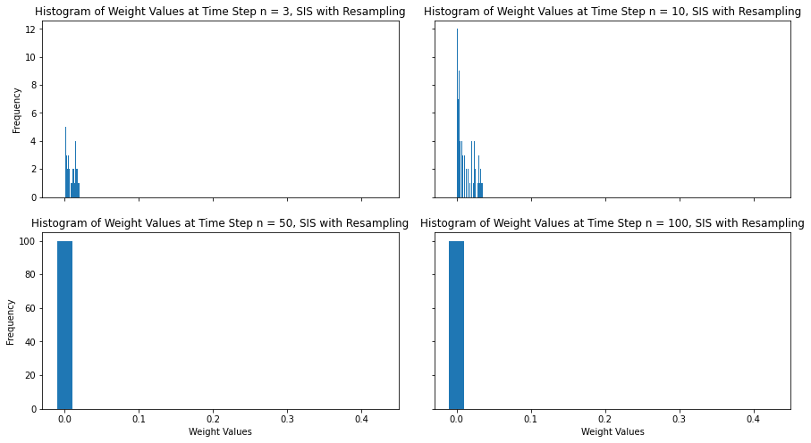

```
Iteration 3 the smallest weight is 0.00091 and the largest one is 0.02029
Iteration 10 the smallest weight is 2e-05 and the largest one is 0.03699
Iteration 50 the smallest weight is 0.01 and the largest one is 0.01
Iteration 100 the smallest weight is 0.01 and the largest one is 0.01
```

```python
n = [3, 10, 50, 100]

i = 0
fig = plt.figure(figsize=(15,8))
gs = fig.add_gridspec(2, 2, hspace=0.2, wspace=0.1)
axs = gs.subplots(sharex='col', sharey='row')
for x in range(2):
    for y in range(2):
        axs[x][y].hist(all_w2[(n[i]-1)*K:n[i]*K], bins=50)
        axs[x][y].set_xlim(-.03, .45)
        axs[x][y].set_title("Histogram of Weight Values at Time Step n = " + str(n[i]) + ", SIS with Resampling")
        i += 1

plt.setp(axs[-1, :], xlabel='Weight Values')
plt.setp(axs[:, 0], ylabel='Frequency')
plt.show()

for i in range(4):
    print("Iteration " + str(n[i]) + " the smallest weight is " + str(round(all_w2[(n[i]-1)*K:n[i]*K].min(),5)) + " and the largest one is " + str(round(all_w2[(n[i]-1)*K:n[i]*K].max(),5)))
```

### Answers to Q3.2 & Q3.3 (2)

*Resampling seems to mitigate the particle degeneracy problem, as we see no path having the weight of 0 (no "dead" particles) at any time step. This is because once we detect a particle that is just "dead" at the previous time step, we rejuvenate that particle by doing a resampling using one of the surviving particles as a seed with selection probability proportional to their corresponding weight (so, usually the "fittest" particle with maximum weight is selected). Actually, we killed off and resample all the particles not selected as a seed and reset the current weight to 1/K (K = the number of particles).*

### Answer to Q3.4

*With K = 5: Without Resampling, RMSE = 6.6253; With Resampling, RMSE = 4.4906*

*With K = 100: Without Resampling, RMSE = 5.2881; With Resampling, RMSE = 0.9673*

*With K = 500: Without Resampling, RMSE = 4.3996; With Resampling, RMSE = 1.0995*

# *4. Bootstrap Particle Filter*

Here you will implement the bootstrap particle filter (BPF). First, you will do resampling at every time step, $n$.

1. How does the update equation for the importance weights change now that we resample at each $n$?

Do the following items using **first multinomial resampling, then stratified resampling**:

1. Estimate $x_n$ at each time step $n$.
2. Visualize the degeneracy of the importance weights using a histogram for $n=2, 5, 50, 100$
3. Visualize the path/trajectory degeneracy by sampling from your BPF approximation of $p(x_{1:T}|y_{1:T})$.

In the title of your plots, state which resampling scheme you used to produce the corresponding results. Use $K=100$.

```python
# Implement BPF here (with multinomial resampling)
np.random.seed(173710)

K = 100  #nr. of particles to generate
N = 100  #nr. of time steps

xgen_n = {}
w_n = {}

xgen_n[0] = np.random.normal(loc=0, scale=(sigma**2/(1-alpha**2)), size=K) #because q(x_1) = p(x_1)
w_n[0] = np.repeat(1/K, K)

for n in range(1,N):
    u = np.random.uniform(0, 1, size=K)
    cum_w_prev_n = np.array([w_n[n-1][:k].sum() for k in range(1,K+1)])
    a_n = [next(x[0] for x in enumerate(cum_w_prev_n) if x[1] > u[k]) for k in range(K)]
    xgen_n[n] = np.random.normal(loc=(alpha*xgen_n[n-1][a_n]), scale=(sigma**2))
    w_n[n] = norm.pdf(y_n[n], loc=0, scale=((beta**2)*np.exp(xgen_n[n])))
    w_n[n] /= w_n[n].sum()
```

```python
all_w3 = np.empty(0)
all_xgen3 = np.empty(0)
for (key1,values1), (key2,values2) in zip(w_n.items(), xgen_n.items()):
    all_w3 = np.append(all_w3, copy.deepcopy(values1))
    all_xgen3 = np.append(all_xgen3, copy.deepcopy(values2))
```

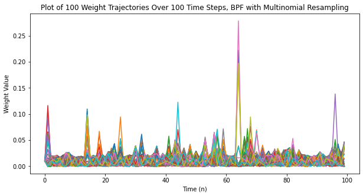

```python
for k in range(K):
    plt.plot(all_w3[np.arange(k, all_w3.size, K)])

plt.xlabel("Time (n)")
plt.ylabel("Weight Value")
plt.title("Plot of " + str(K) + " Weight Trajectories Over 100 Time Steps, BPF with Multinomial Resampling")
plt.show()
```

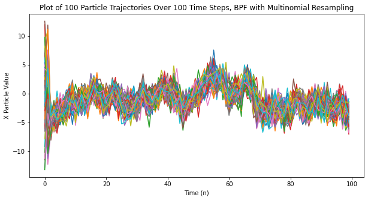

```python
for k in range(N):
    plt.plot(all_xgen3[np.arange(k, all_xgen3.size, K)])

plt.xlabel("Time (n)")
plt.ylabel("X Particle Value")
plt.title("Plot of " + str(K) + " Particle Trajectories Over 100 Time Steps, BPF with Multinomial Resampling")
plt.show()
```

```python
xhat3_n = [np.dot(all_xgen3[n:(n+K)], all_w3[n:(n+K)]) for n in range(0, len(all_xgen3), K)]
print(xhat3_n)
```

```
[-0.2782696236634674, -4.830112551937464, -4.709356411725237, -4.0190294769334365, -3.4597474574000255, -3.223874936901657, -2.169988187161291, -0.9928508628681143, -1.50903422906122, -1.9710747467170648, -1.574502572882575, -1.0679393871528595, -1.1473611142239324, -1.28864113305703, 0.466124485350…
```

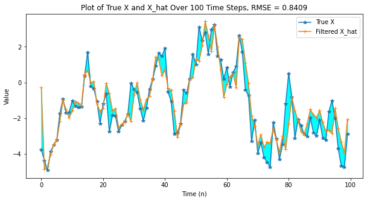

```python
rmse = ((xhat3_n - x_n)**2).mean()

plt.rc("figure", figsize=(10,5))
plt.plot(x_n, '*-')
plt.plot(xhat3_n, '+-')
plt.fill_between(np.arange(N), x_n, xhat3_n, color="cyan")
plt.xlabel("Time (n)")
plt.ylabel("Value")
plt.legend(["True X", "Filtered X_hat"])
plt.title("Plot of True X and X_hat Over 100 Time Steps, RMSE = " + str(round(rmse,4)))
```

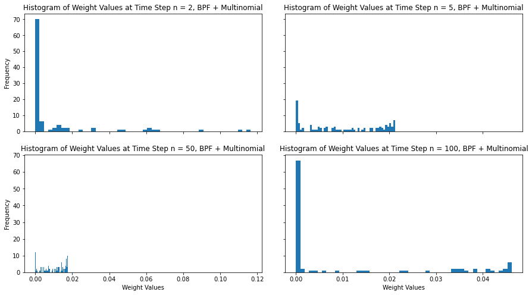

```
Iteration 2 the smallest weight is 0.0 and the largest one is 0.11644
Iteration 5 the smallest weight is 0.0 and the largest one is 0.02123
Iteration 50 the smallest weight is 0.0 and the largest one is 0.01764
Iteration 100 the smallest weight is 0.0 and the largest one is 0.0462
```

```python
n = [2, 5, 50, 100]

i = 0
fig = plt.figure(figsize=(15,8))
gs = fig.add_gridspec(2, 2, hspace=0.2, wspace=0.1)
axs = gs.subplots(sharex='col', sharey='row')
for x in range(2):
    for y in range(2):
        axs[x][y].hist(all_w3[(n[i]-1)*K:n[i]*K], bins=50)
        axs[x][y].set_title("Histogram of Weight Values at Time Step n = " + str(n[i]) + ", BPF + Multinomial")
        i += 1

plt.setp(axs[-1, :], xlabel='Weight Values')
plt.setp(axs[:, 0], ylabel='Frequency')
plt.show()

for i in range(4):
    print("Iteration " + str(n[i]) + " the smallest weight is " + str(round(all_w3[(n[i]-1)*K:n[i]*K].min(),5)) + " and the largest one is " + str(round(all_w3[(n[i]-1)*K:n[i]*K].max(),5)))
```

```python
# Implement BPF here (with stratified resampling)
np.random.seed(173710)

K = 100  #nr. of particles to generate
N = 100  #nr. of time steps

xgen_n = {}
w_n = {}

xgen_n[0] = np.random.normal(loc=0, scale=(sigma**2/(1-alpha**2)), size=K) #because q(x_1) = p(x_1)
w_n[0] = np.repeat(1/K, K)

nr_strata = 10
for n in range(1,N):
    which_strata = np.random.randint(0, nr_strata, K)
    u = np.random.uniform((which_strata/nr_strata), ((which_strata+1)/nr_strata))
    cum_w_prev_n = np.array([w_n[n-1][:k].sum() for k in range(1,K+1)])
    a_n = [next(x[0] for x in enumerate(cum_w_prev_n) if x[1] > u[k]) for k in range(K)]
    xgen_n[n] = np.random.normal(loc=(alpha*xgen_n[n-1][a_n]), scale=(sigma**2))
    w_n[n] = norm.pdf(y_n[n], loc=0, scale=((beta**2)*np.exp(xgen_n[n])))
    w_n[n] /= w_n[n].sum()
```

```python
all_w4 = np.empty(0)
all_xgen4 = np.empty(0)
for (key1,values1), (key2,values2) in zip(w_n.items(), xgen_n.items()):
    all_w4 = np.append(all_w4, copy.deepcopy(values1))
    all_xgen4 = np.append(all_xgen4, copy.deepcopy(values2))
```

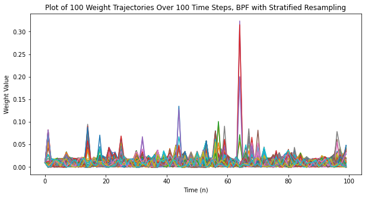

```python
for k in range(K):
    plt.plot(all_w4[np.arange(k, all_w4.size, K)])

plt.xlabel("Time (n)")
plt.ylabel("Weight Value")
plt.title("Plot of " + str(K) + " Weight Trajectories Over 100 Time Steps, BPF with Stratified Resampling")
plt.show()
```

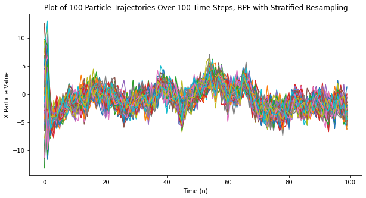

```python
for k in range(N):
    plt.plot(all_xgen4[np.arange(k, all_xgen4.size, K)])

plt.xlabel("Time (n)")
plt.ylabel("X Particle Value")
plt.title("Plot of " + str(K) + " Particle Trajectories Over 100 Time Steps, BPF with Stratified Resampling")
plt.show()
```

```python
xhat4_n = [np.dot(all_xgen4[n:(n+K)], all_w4[n:(n+K)]) for n in range(0, len(all_xgen4), K)]
print(xhat4_n)
```

```
[-0.2782696236634674, -5.369034158379121, -4.829150822699212, -4.0846593404940315, -3.466862661584562, -3.256862942576379, -2.2420339366224296, -1.1148083628545882, -1.7344012824750052, -2.0234113073847833, -1.5690964921142765, -1.0504431002736587, -1.1393914186504535, -1.2784801731186273, 0.7388805…
```

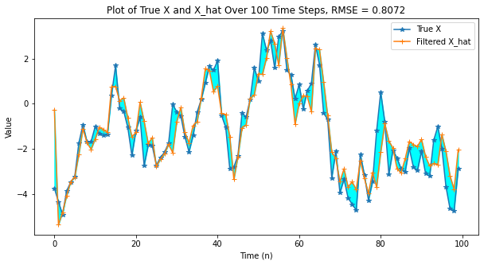

```python
rmse = ((xhat4_n - x_n)**2).mean()

plt.rc("figure", figsize=(10,5))
plt.plot(x_n, '*-')
plt.plot(xhat4_n, '+-')
plt.fill_between(np.arange(N), x_n, xhat4_n, color="cyan")
plt.xlabel("Time (n)")
plt.ylabel("Value")
plt.legend(["True X", "Filtered X_hat"])
plt.title("Plot of True X and X_hat Over 100 Time Steps, RMSE = " + str(round(rmse,4)))
```

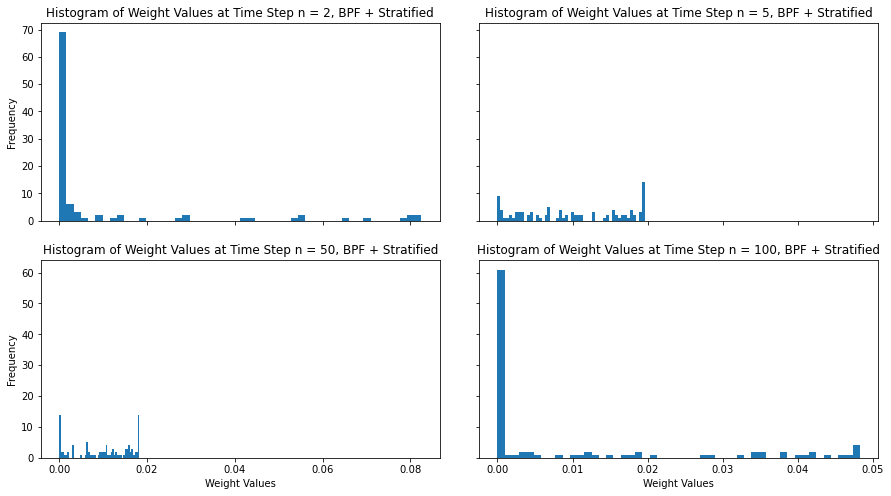

```
Iteration 2 the smallest weight is 0.0 and the largest one is 0.08251
Iteration 5 the smallest weight is 0.0 and the largest one is 0.01959
Iteration 50 the smallest weight is 0.0 and the largest one is 0.0183
Iteration 100 the smallest weight is 0.0 and the largest one is 0.04828
```

```python
n = [2, 5, 50, 100]

i = 0
fig = plt.figure(figsize=(15,8))
gs = fig.add_gridspec(2, 2, hspace=0.2, wspace=0.1)
axs = gs.subplots(sharex='col', sharey='row')
for x in range(2):
    for y in range(2):
        axs[x][y].hist(all_w4[(n[i]-1)*K:n[i]*K], bins=50)
        axs[x][y].set_title("Histogram of Weight Values at Time Step n = " + str(n[i]) + ", BPF + Stratified")
        i += 1

plt.setp(axs[-1, :], xlabel='Weight Values')
plt.setp(axs[:, 0], ylabel='Frequency')
plt.show()

for i in range(4):
    print("Iteration " + str(n[i]) + " the smallest weight is " + str(round(all_w4[(n[i]-1)*K:n[i]*K].min(),5)) + " and the largest one is " + str(round(all_w4[(n[i]-1)*K:n[i]*K].max(),5)))
```

# *5. Parameter Inference using the Marginal Likelihood*

In SMC methods, the parameters of the model, $\theta$, are often unknown. In the SV model above, we assumed that the parameter values were $\theta=(\beta, \alpha, \sigma^2) = (0.64, 0.91, 1)$, and generated data using these values. Here, you are instead given observations, $y_{1:T}$, generated by some *unknown* parameters and $x_{1:T}$. How does one decide which parameters to use in order to infer the latent variables, $x_{1:T}$?

In the next assignment you will infer the parameters in a more sophisticated manner, using the particle Gibbs algorithm. For now you will use brute force to find a viable solution, namely through a grid search. You are to iterate over different combinations of $\theta$, and for each combination compute the marginal log-likelihood $\log p(y_{1:T}|\theta)$ (log for numerical stability).

Use the BPF algorithm and resample at every $n$. In the text cell below, type the expression for this the corresponding approximation of $p(y_{1:T}|\theta)$ (you can find it in the lecture slides):

*Type the expression for the approximation of $p(y_{1:T}|\theta)$ here, given that you use the BPF and do resampling every time step*

*Answer:*

\begin{equation} p(y_{1:T}|\theta) \approx \prod_{i=1}^T \frac{1}{K}\sum_k^K p(y_i | x_i^k, \theta) \end{equation}

Make a reasonably coarse grid (say, $8\times8\times 8$) for $\theta$ in the interval ($0$, $1$). Use the BPF with Multinomial resampling and $K=100$ to estimate the marginal log-likelihood for each pair of $\theta$ in the grid. Run the BPF 10 times (each with different random seed) for each parameter combination, and average your estimates.

Based on your results, which parameter combination would you choose?

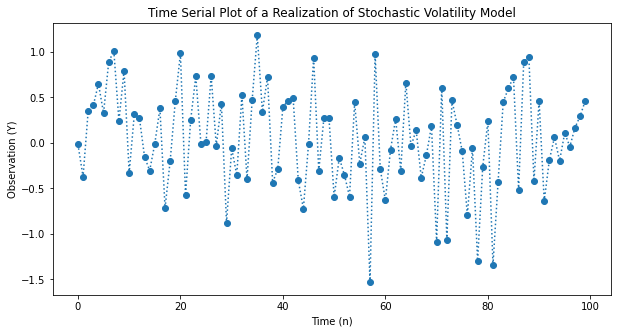

```python
# load observations.npy from Canvas and do the grid search below
sv_obs = np.load("observations.npy")

plt.rc("figure", figsize=(10,5))
plt.plot(sv_obs, ':o')
plt.xlabel("Time (n)")
plt.ylabel("Observation (Y)")
plt.title("Time Serial Plot of a Realization of Stochastic Volatility Model")
plt.show()
```

```python
def LL_BPF(data, theta, K, seed):
    """data is an array of N observations
       theta is a dictionary of parameters and their values
       K is the number of particles"""

    np.random.seed(seed)
    cum_LL_n = []
    beta = theta[0]
    alpha = theta[1]
    sigma_sq = theta[2]

    xgen_n = np.random.normal(loc=0, scale=(sigma_sq/(1-alpha**2)), size=K) #because q(x_1) = p(x_1)
    w_n = np.repeat(1/K, K)
    cum_LL_n = np.append(cum_LL_n, norm.logpdf(data[0], loc=0, scale=((beta**2)*np.exp(xgen_n))).mean())

    for n in range(1, data.size):
        u = np.random.uniform(0, 1, size=K)
        prev_xgen_n = copy.deepcopy(xgen_n)
        cum_w_prev_n = np.array([w_n[:k].sum() for k in range(1,K+1)])
        a_n = [next(x[0] for x in enumerate(cum_w_prev_n) if x[1] > u[k]) for k in range(K)]
        xgen_n = np.random.normal(loc=(alpha*prev_xgen_n[a_n]), scale=(sigma_sq))
        cum_LL_n = np.append(cum_LL_n, cum_LL_n[n-1] + norm.logpdf(data[n], loc=0, scale=((beta**2)*np.exp(xgen_n))).mean())

    return(cum_LL_n)
```

```python
t0 = time.time()

theta ={"beta":np.linspace(.05, 1, 20), "alpha":np.linspace(0, .95, 20), "sigma_sq":np.linspace(.1, 1, 10)**2}
K = 100
seeds = np.random.randint(1, 1000, 10)

Results = {}

for seed in seeds:
    LL = {}
    params = {}
    i = 0
    for b in theta["beta"]:
        for a in theta["alpha"]:
            for s2 in theta["sigma_sq"]:
                LL[i] = LL_BPF(sv_obs, (b,a,s2), K, seed)
                params[i] = np.array([b, a, s2])
                i += 1

    Results[seed] = LL

t1 = time.time()
total_time = t1 - t0
print('total time is', total_time//3600, 'hour', (total_time%3600)//60, 'minute', (total_time%3600)%60, 'seconds')
```

```
total time is 1.0 hour 11.0 minute 28.356043338775635 seconds
```

```python
s = 0
Report = {}
for seed,LL in Results.items():
    full_data_LL = np.empty(0)
    for _,values2 in Results[seed].items():
        full_data_LL = np.append(full_data_LL, values2[-1])

    Report[s] = (seed, full_data_LL.max(), np.where(full_data_LL == full_data_LL.max())[0][0])
    print("Seed " + str(Report[s][0]) +": The maximum log-likelihood of BPF with " + str(K) + " particles is " + str(round(Report[s][1],4)) + " and is achieved with [\u03B2, \u03B1, \u03C3\N{SUPERSCRIPT TWO}] = " + str(params[Report[s][2]]))
    s += 1
```

```
Seed 172: The maximum log-likelihood of BPF with 100 particles is -83.3632 and is achieved with [β, α, σ²] = [0.75 0.   0.01]
Seed 761: The maximum log-likelihood of BPF with 100 particles is -83.3296 and is achieved with [β, α, σ²] = [0.75 0.   0.01]
Seed 447: The maximum log-likelihood of BPF with 100 particles is -83.3199 and is achieved with [β, α, σ²] = [0.75 0.45 0.01]
Seed 919: The maximum log-likelihood of BPF with 100 particles is -83.3163 and is achieved with [β, α, σ²] = [0.75 0.45 0.01]
Seed 164: The maximum log-likelihood of BPF with 100 particles is -83.3384 and is achieved with [β, α, σ²] = [0.75 0.   0.01]
Seed 324: The maximum log-likelihood of BPF with 100 particles is -83.3194 and is achieved with [β, α, σ²] = [0.75 0.25 0.01]
Seed 295: The maximum log-likelihood of BPF with 100 particles is -83.3278 and is achieved with [β, α, σ²] = [0.75 0.   0.01]
Seed 527: The maximum log-likelihood of BPF with 100 particles is -83.3329 and is achieved with [β, α, σ²] = [0.75 0.3  0.01]
Seed 573: The maximum log-likelihood of BPF with 100 particles is -83.3513 and is achieved with [β, α, σ²] = [0.75 0.65 0.01]
Seed 59: The maximum log-likelihood of BPF with 100 particles is -83.3382 and is achieved with [β, α, σ²] = [0.75 0.   0.01]
```

*Based on the 10 results, I would recommend $\theta = (\beta, \alpha, \sigma^2) = (.75, .21, .01)$*